# Solving linear systems numerically

Numerical Analysis

Urbain Vaes

NYU Paris

## Objective

**Goal of this chapter**

Study numerical methods for the linear equation
$$\mathsf A \mathbf{\boldsymbol{x}} = \mathbf{\boldsymbol{b}},$$
where $\mathsf A \in \mathbf C^{n \times n}$ and $b \in \mathbf C^n.$

Two classes of methods:

- **Direct methods**:
  - LU decomposition (for general invertible matrices);
  - Cholesky decomposition (for symmetric positive definite matrices)
- **Iterative methods**:
  - Basic iterative methods based on a splitting;
  - Conjugate gradients;
  - And many more: GMRES, BiCGStab, etc.

Before discussing these methods, we introduce the concept of **conditioning**.

# Conditioning of linear systems

- Assume that we wish to calculate numerically the solution $(1, -1)^T$ of
  $$\mathsf A \mathbf{\boldsymbol{x}} :=
  \begin{pmatrix}
  1 & 1 \\
  1 & 1 - 10^{-12}
  \end{pmatrix}
  \begin{pmatrix}
  x_1 \\
  x_2
  \end{pmatrix} =
  \begin{pmatrix}
  0 \\
  10^{-12}
  \end{pmatrix} =: \mathbf{\boldsymbol{b}}.$$
- In Julia, we can calculate the solution with the `\` operator

  ```julia
  A = [1 1; 1 (1-1e-12)]
  b = [0; 1e-12]
  x = A\b
  ```

  ```
  2-element Vector{Float64}:
    1.0000221222095027
   -1.0000221222095027
  ```

  Why is the relative error much larger than the *machine epsilon*?
- Julia solves not $\mathsf A \mathbf{\boldsymbol{x}} = \mathbf{\boldsymbol{b}}$ but
  $$(\mathsf A + \Delta \mathsf A) (\mathbf{\boldsymbol{x}} + \Delta \mathbf{\boldsymbol{x}}) = (\mathbf{\boldsymbol{b}} + \Delta \mathbf{\boldsymbol{b}})$$
  where $\Delta \mathsf A$ and $\Delta \mathbf{\boldsymbol{b}}$ are roundoff errors, and $\Delta \mathbf{\boldsymbol{x}}$ is the resulting perturbation of the solution.

**Question**: Can we estimate $\frac{{\lVert {\Delta \mathbf{\boldsymbol{x}}} \rVert}}{{\lVert {\mathbf{\boldsymbol{x}}} \rVert}}$ in terms of $\frac{{\lVert {\Delta \mathsf A} \rVert}}{{\lVert {\mathsf A} \rVert}}$ and $\frac{{\lVert {\Delta \mathbf{\boldsymbol{b}}} \rVert}}{{\lVert {\mathbf{\boldsymbol{b}}} \rVert}}$?

## Recalls: vector and matrix norms (1/3)

Given $p \in [1, \infty]$, the $p$-norm of a vector $\mathbf{\boldsymbol{x}} \in \mathbf C^n$ is defined as follows:
$${\lVert {\mathbf{\boldsymbol{x}}} \rVert}_p :=
\begin{cases}
\left( \sum_{i=1}^{n} {\lvert {x_i} \rvert}^p \right)^{\frac{1}{p}} & \text{if $p < \infty$}, \\
\max \Bigl\{ {\lvert {x_1} \rvert}, \dotsc, {\lvert {x_n} \rvert} \Bigr\} & \text{if $p = \infty$}.
\end{cases}$$
In Julia, calculate ${\lVert {\mathbf{\boldsymbol{x}}} \rVert}_p$ using `norm(x, p)`.

```julia
Plots.plot(aspect_ratio=:equal, xlims=(-1.1,1.1), ylims=(-1.1, 1.1))
Plots.plot!(framestyle=:origin, grid=true, legend=:outertopright)
Plots.plot!(title="Unit circle in different norms")
Plots.plot!([0, 1, 0, -1, 0], [-1, 0, 1, 0, -1], label=L"$p = 1$ (taxicab norm)")
Plots.plot!(t -> cos(t), t -> sin(t), 0, 2π, label=L"$p = 2$ (Euclidean norm)")
Plots.plot!([1, 1, -1, -1, 1], [1, -1, -1, 1, 1], label=L"p = \infty")
```

[figure not shown]

## Recalls: vector and matrix norms (2/3)

The operator norm on matrices induced by the vector $p$-norm is given by
$${\lVert {\mathsf A} \rVert}_{p} := \sup_{{\lVert {\mathbf{\boldsymbol{x}}} \rVert}_{p} \leqslant 1} {\lVert {\mathsf A \mathbf{\boldsymbol{x}}} \rVert}_{p}$$
It follows from the definition that ${\lVert {\mathsf A \mathsf B} \rVert}_p \leqslant{\lVert {\mathsf A} \rVert}_p {\lVert {\mathsf B} \rVert}_p$. In Julia, calculate ${\lVert {\mathsf A} \rVert}_p$ using `opnorm(A, p)`.

**Exercises**

Show that

- The matrix 2-norm is given by $\sqrt{\lambda_{\rm max}(\mathsf A^* \mathsf A)}$.
- The matrix 1-norm is the maximum absolute column sum:

  $${\lVert {\mathsf A} \rVert}_1 = \max_{1 \leqslant j \leqslant n} \sum_{i=1}^{n} {\lvert {a_{ij}} \rvert}.$$
- The matrix $\infty$-norm is the maximum absolute row sum:

  $${\lVert {\mathsf A} \rVert}_{\infty} = \max_{1 \leqslant i \leqslant n} \sum_{j=1}^{n} {\lvert {a_{ij}} \rvert}.$$

## Recalls: vector and matrix norms (3/3)

From matrix norms, we define the **condition number** of a matrix as
$$\kappa_p(\mathsf A) = {\lVert {\mathsf A} \rVert}_p {\lVert {\mathsf A^{-1}} \rVert}_p$$

**Properties**:

- $\kappa_p(\mathsf I) = 1$
- $\kappa_p(\mathsf A) \geqslant 1$
- $\kappa_p(\alpha \mathsf A) = \kappa_p(\mathsf A)$

In Julia, calculate the condition number using `cond(A, p)`.

## Conditioning of linear systems

**Proposition**

Let $\mathbf{\boldsymbol{x}} + \Delta \mathbf{\boldsymbol{x}}$ denote the solution to
$$\mathsf A (\mathbf{\boldsymbol{x}} + \Delta \mathbf{\boldsymbol{x}}) = \mathbf{\boldsymbol{b}} + \Delta \mathbf{\boldsymbol{b}}$$
The following inequality holds:
$$\frac{{\lVert {\Delta \mathbf{\boldsymbol{x}}} \rVert}}{{\lVert {\mathbf{\boldsymbol{x}}} \rVert}}
\leqslant\kappa(\mathsf A) \frac{{\lVert {\Delta \mathbf{\boldsymbol{b}}} \rVert}}{{\lVert {\mathbf{\boldsymbol{b}}} \rVert}}$$

**Proof**

It holds by definition of $\Delta \mathbf{\boldsymbol{x}}$ that $\mathsf A \Delta \mathbf{\boldsymbol{x}} = \Delta \mathbf{\boldsymbol{b}}$. Therefore
$$\begin{aligned}
{\lVert {\Delta \mathbf{\boldsymbol{x}}} \rVert}
&= {\lVert {\mathsf A^{-1} \Delta \mathbf{\boldsymbol{b}}} \rVert}
\leqslant{\lVert {\mathsf A^{-1}} \rVert} {\lVert {\Delta \mathbf{\boldsymbol{b}}} \rVert} \\
&= \frac{{\lVert {\mathsf A \mathbf{\boldsymbol{x}}} \rVert}}{{\lVert {\mathbf{\boldsymbol{b}}} \rVert}} {\lVert {\mathsf A^{-1}} \rVert} {\lVert {\Delta \mathbf{\boldsymbol{b}}} \rVert}
\leqslant\frac{{\lVert {\mathsf A} \rVert} {\lVert {\mathbf{\boldsymbol{x}}} \rVert}}{{\lVert {\mathbf{\boldsymbol{b}}} \rVert}} {\lVert {\mathsf A^{-1}} \rVert} {\lVert {\Delta \mathbf{\boldsymbol{b}}} \rVert}.
\end{aligned}$$
Rearranging, we obtain the statement.

**Proposition**

Let $\mathbf{\boldsymbol{x}} + \Delta \mathbf{\boldsymbol{x}}$ denote the solution to
$$(\mathsf A + \Delta \mathsf A) (\mathbf{\boldsymbol{x}} + \Delta \mathbf{\boldsymbol{x}}) = \mathbf{\boldsymbol{b}}$$
If $\mathsf A$ is invertible and ${\lVert {\Delta \mathsf A} \rVert} < \frac{1}{2} {\lVert {\mathsf A^{-1}} \rVert}^{-1}$, then
$$\frac{{\lVert {\Delta \mathbf{\boldsymbol{x}}} \rVert}}{{\lVert {\mathbf{\boldsymbol{x}}} \rVert}}
\leqslant 2\kappa(\mathsf A) \frac{{\lVert {\Delta \mathsf A} \rVert}}{{\lVert {\mathsf A} \rVert}}$$

Conclusion: $\kappa(\mathsf A)$ measures sensitivity to perturbations:

- useful to estimate the impact of round-off errors;
- influences convergence speed of methods (see later).
- When $\kappa_p(\mathsf A) \gg 1$, the system is called **ill-conditioned**.

# Direct methods

- First calculate the $\mathsf L \mathsf U$ decomposition of $\mathsf A$ with
  - $\mathsf U$ upper triangular matrix;
  - $\mathsf L$ unit lower triangular.
- Then solve $\mathsf L \mathbf{\boldsymbol{y}} = \mathbf{\boldsymbol{b}}$ using *forward substitution*.

  ```julia
  y = copy(b)
  for i in 2:n
      for j in 1:i-1
          y[i] -= L[i, j] * y[j]
      end
  end
  ```

- Finally, solve $\mathsf U \mathbf{\boldsymbol{x}} = \mathbf{\boldsymbol{y}}$ using *backward substitution*.

**Remark: The LU decomposition may not exist**

In practice, use decomposition $\mathsf P \mathsf A = \mathsf L \mathsf U$, with $\mathsf P$ a permutation matrix.

- Guaranteed to exist if $\mathsf A$ is invertible;
- More numerically stable.

## LU decomposition by Gaussian elimination

$$\underbrace{
\begin{pmatrix}
2 & 1 & -1 \\
-3 & -1 & 2 \\
-2 & 1 & 2
\end{pmatrix}
}_{\mathsf A}$$

$$\underbrace{
\begin{pmatrix}
1 & 0 & 0 \\
{\color{red}\frac{3}{2}} & 1 & 0 \\
{\color{red}{1}} & 0 & 1
\end{pmatrix}
}_{=: \, \mathsf M_1}~
\underbrace{
\begin{pmatrix}
2 & 1 & -1 \\
-3 & -1 & 2 \\
-2 & 1 & 2
\end{pmatrix}
}_{\mathsf A}
=
\begin{pmatrix}
2 & 1 & -1 \\
{\color{red} 0} & \frac{1}{2} & \frac{1}{2} \\
{\color{red} 0} & 2 & 1
\end{pmatrix}$$

$$\underbrace{
\begin{pmatrix}
1 & 0 & 0 \\
0 & 1 & 0 \\
0 & {\color{blue} -4} & 1
\end{pmatrix}
}_{=: \, \mathsf M_2}~
\underbrace{
\begin{pmatrix}
1 & 0 & 0 \\
{\color{red}\frac{3}{2}} & 1 & 0 \\
{\color{red}{1}} & 0 & 1
\end{pmatrix}
}_{=: \, \mathsf M_1}~
\underbrace{
\begin{pmatrix}
2 & 1 & -1 \\
-3 & -1 & 2 \\
-2 & 1 & 2
\end{pmatrix}
}_{\mathsf A}
=
\underbrace{
\begin{pmatrix}
2 & 1 & -1 \\
{\color{red} 0} & \frac{1}{2} & \frac{1}{2} \\
{\color{red} 0} & {\color{blue} 0} & -1
\end{pmatrix}
}_{=: \, \mathsf U}$$

Gaussian transformations $\mathsf M_1$, $\mathsf M_2$ are simple to invert and multiply. In particular
$$\mathsf A = \mathsf M_1^{-1} \mathsf M_2^{-1} \mathsf U
= \underbrace{
\begin{pmatrix}
1 & 0 & 0 \\
{\color{red}-\frac{3}{2}} & 1 & 0 \\
{\color{red}{-1}} & 0 & 1
\end{pmatrix}
}_{=: \, \mathsf M_1^{-1}}~
\underbrace{
\begin{pmatrix}
1 & 0 & 0 \\
0 & 1 & 0 \\
0 & {\color{blue} 4} & 1
\end{pmatrix}
}_{=: \, \mathsf M_2^{-1}}~
\mathsf U
= \underbrace{
\begin{pmatrix}
1 & 0 & 0 \\
{\color{red}-\frac{3}{2}} & 1 & 0 \\
{\color{red}{-1}} & {\color{blue} 4} & 1
\end{pmatrix}
}_{\mathsf M_1^{-1} \mathsf M_2^{-1} =: \, \mathsf L}~
\mathsf U$$

## LU decomposition: computational cost

```julia
# A is an invertible matrix of size n x n
L = [r == c ? 1.0 : 0.0 for r in 1:n, c in 1:n]
U = copy(A)
for c in 1:n-1, r in c+1:n
   U[c, c] == 0 && error("Pivotal entry is zero!")
   L[r, c] = U[r, c] / U[c, c]
   U[r, c:end] -= U[c, c:end] * L[r, c]
end
# L is unit lower triangular and U is upper triangular
```

$~$

- Computational cost: $\frac{2}{3} n^3 + \mathcal O(n^2)$ floating point operations (flops);
- In comparison, the computational cost of forward/backward substitution scales as $\mathcal O(n^2)$;
- The LU decomposition can be reused for different right-hand sides;
- If $\mathsf A$ is a banded matrix, so are $\mathsf L$ and $\mathsf U$, with the same bandwidth;
- $\mathsf L$ and $\mathsf U$ are not necessarily sparse when $\mathsf A$ is sparse.

## Direct method for symmetric positive definite $\mathsf A$

- It is more efficient to calculate the *Cholesky factorization* $\mathsf A = \mathsf C \mathsf C^*$ with $\mathsf C$ lower triangular with positive diagonal elements.
- Determination of $\mathsf C$ by identification column by column, first the diagonal term then the other terms:
  $$a_{ij}=\sum_{k=1}^{\min{(i,j)}}c_{ik}\overline{c_{jk}} \quad ⇒\quad ∀j=1\ldots n\quad c_{jj}=\sqrt{a_{jj}-\sum_{k=1}^{j-1}\lvert c_{jk}\rvert^2} \quad\textrm{ and }\quad ∀i=j+1\ldots n \quad c_{ij}=\frac{a_{ij}-\sum_{k=1}^{j-1}c_{ik}\overline{c_{jk}}}{c_{jj}}$$

```julia
function cholesky(A)
    n = size(A, 1)
    C = copy(LowerTriangular(A))
    for j ∈ 1:n
        Cⱼₖ = C[j, 1:j-1]
        C[j,j] -= Cⱼₖ'Cⱼₖ
        C[j,j] = √C[j,j]
        for i ∈ j+1:n
            C[i,j] -= Cⱼₖ'C[i, 1:j-1]
            C[i,j] = C[i,j]/C[j,j]
        end
    end
    return C
end
```

```julia
using Polynomials
function generate_defpos_matrix(n)
    A = rand(n,n)
    return A'A+I
end

A = generate_defpos_matrix(2^7) ; C = cholesky(A)
# println("||A - CC*||_∞ = ", norm(A-C'C, Inf))

nb_samples = 10
mean(x) = sum(x)/length(x)
Plots.plot(xaxis=:log10, yaxis=:log10, xlabel="n", ylabel="CPU time", legend=:topleft, size=(900,400))
tf = Float64[] ; tb = Float64[]
tn = 2 .^(7:10)
for n in tn
    A = generate_defpos_matrix(n)
    push!(tf, mean(@elapsed cholesky(A) for _ in 1:nb_samples))
end
Pf = fit(log10.(tn),log10.(tf),1) ; af = round(coeffs(Pf)[2]; digits=2)
Plots.plot!(tn, tf, marker=:o, label="Dense matrix "*latexstring("n^{$(af)}"))
```

[figure not shown]

## Cholesky for banded matrices

- $\mathsf A$ is a banded matrix i.e. it exists $b\in{\mathbb{{N}}}$ such that $a_{ij}=0$ if $|i-j|>b$.
- It follows that $\mathsf C$ is also a banded matrix with the same bandwidth.

$$∀j=1\ldots n\quad c_{jj}=\sqrt{a_{jj}-\sum_{k=\max{(1,j-b)}}^{j-1}\lvert c_{jk}\rvert^2} \quad\textrm{ and }\quad ∀i=j+1\ldots \min{(n,j+b)} \quad c_{ij}=\frac{a_{ij}-\sum_{k=\max{(1,j-b)}}^{j-1}c_{ik}\overline{c_{jk}}}{c_{jj}}$$

```julia
function cholesky_banded(A, b)
    n = size(A, 1)
    C = copy(LowerTriangular(A))
    for j ∈ 1:n
        m, M = max(1,j-b), min(n,j+b)
        Cⱼₖ = C[j, m:j-1]
        C[j,j] -= Cⱼₖ'Cⱼₖ
        C[j,j] = √C[j,j]
        for i ∈ j+1:M
            C[i,j] -= Cⱼₖ'C[i, m:j-1]
            C[i,j] = C[i,j]/C[j,j]
        end
    end
    return C
end
```

```julia
function generate_banded_matrix(n, b)
    C = [j≤i≤j+b ? rand() : zero(Float64) for i in 1:n, j in 1:n]
    return C*C'+I
end

n = 10 ; b = 4
A = generate_banded_matrix(n,b)
C = cholesky_banded(A,b)
# println("||A - CC*||_∞ = ", norm(A-C'C, Inf))

nb_samples = 10
mean(x) = sum(x)/length(x)
Plots.plot(xaxis=:log10, yaxis=:log10, xlabel="n", ylabel="CPU time", legend=:topleft, size=(900,400))
tf = Float64[] ; tb = Float64[]
tn = 2 .^(7:10)
for n in tn
    A = generate_banded_matrix(n, b)
    push!(tf, mean(@elapsed cholesky(A) for _ in 1:nb_samples))
    push!(tb, mean(@elapsed cholesky_banded(A,b) for _ in 1:nb_samples))
end
Pf = fit(log10.(tn),log10.(tf),1) ; af = round(coeffs(Pf)[2]; digits=2)
Plots.plot!(tn, tf, marker=:o, label="Dense matrix "*latexstring("n^{$(af)}"))
ntn = 2 .^(11:12)
for n in ntn
    A = generate_banded_matrix(n, b)
    push!(tb, mean(@elapsed cholesky_banded(A,b) for _ in 1:nb_samples))
end
append!(tn,ntn)
Pb = fit(log10.(tn),log10.(tb),1) ; ab = round(coeffs(Pb)[2]; digits=2)
Plots.plot!(tn, tb, marker=:diamond, label="Banded matrix "*latexstring("n^{$(ab)}"))
```

[figure not shown]

# Iterative methods

**Motivation**: General-purpose direct methods are

- exact up to roundoff errors
- but computationally expensive: $\mathcal O(n^3)$ flops for full matrices…
- Additionally, they require the storage of $\mathsf L$ and $\mathsf U$.

$~$

In contrast, iterative methods

- are usually approximate (but there are exceptions);
- usually have a cost per iteration scaling as $\mathcal O(n^2)$ at most;

  $\rightarrow$ often computationally more economical
- can be stopped at any point when the residual $\mathsf A \mathbf{\boldsymbol{x}} - \mathbf{\boldsymbol{b}}$ is sufficiently small;

$~$

## A first iterative method

**Richardson’s method**

$$\begin{align*}
\mathbf{\boldsymbol{x}}^{(k + 1)} = \mathbf{\boldsymbol{x}}^{(k)} + \omega (\mathbf{\boldsymbol{b}} - \mathsf A \mathbf{\boldsymbol{x}}^{(k)})
\end{align*}$$

**Proposition**

Assume $\omega \neq 0$. If $(\mathbf{\boldsymbol{x}}^{(k)})$ converges in the iteration above, then it converges towards the solution of
$$\begin{align*}
\mathsf A \mathbf{\boldsymbol{x}} = \mathbf{\boldsymbol{b}}.
\end{align*}$$

**Questions:**

- Does this method converge and how quickly?
- What is a good stopping criterion?

## Spectral radius and Gelfand’s lemma

**Definition**

The spectral radius of $\mathsf A \in \mathbf C^{n \times n}$ is given by
$$\rho(\mathsf A) := \max_{\lambda \in \mathop{\mathrm{spectrum}}A} {\lvert {\lambda} \rvert}$$

**Remarks**:

- $\rho(A)$ is not a norm;
- $\rho(A) \leqslant{\lVert {\mathsf A} \rVert}$ for any induced matrix norm.

**Theorem: Gelfand’s formula**

For any $\mathsf A \in \mathbf C^{n \times n}$ and any matrix norm ${\lVert {\cdot} \rVert}$,
$$\lim_{k \to \infty} {\lVert {\mathsf A^k} \rVert}^{1/k} = \rho(\mathsf A).$$

- In particular ${\lVert {\mathsf A^k} \rVert} \to 0$ as $k \to \infty$ iff $\rho(\mathsf A) < 1$.
- The smaller $\rho(\mathsf A)$, the faster the convergence.

## Analysis of Richardson’s method

$$\begin{align*}
\mathbf{\boldsymbol{x}}^{(k + 1)} = \mathbf{\boldsymbol{x}}^{(k)} + \omega (\mathbf{\boldsymbol{b}} - \mathsf A \mathbf{\boldsymbol{x}}^{(k)})
\end{align*}$$

**Proposition**

The Richardson iteration converges to the real solution for every choice of $\mathbf{\boldsymbol{x}}^{(0)}$ if and only if
$$\begin{align*}
\rho(\mathsf I - \omega \mathsf A) = \max_{\lambda \in \mathop{\mathrm{spectrum}}A} {\lvert {1 - \omega \lambda} \rvert} < 1.
\end{align*}$$

**Proof**

We notice that
$$\mathbf{\boldsymbol{x}}^{(k+1)} - \mathbf{\boldsymbol{x}}_*
= \mathbf{\boldsymbol{x}}^{(k)} - \mathbf{\boldsymbol{x}}_* + \omega (\mathsf A \mathbf{\boldsymbol{x}}_* - \mathsf A \mathbf{\boldsymbol{x}}^{(k)})
= (\mathsf I - \omega \mathsf A) \left( \mathbf{\boldsymbol{x}}^{(k)} - \mathbf{\boldsymbol{x}}_* \right).$$
Therefore
$$\mathbf{\boldsymbol{x}}^{(k)} - \mathbf{\boldsymbol{x}}_* = (\mathsf I - \omega \mathsf A)^k \left( \mathbf{\boldsymbol{x}}^{(0)} - \mathbf{\boldsymbol{x}}_* \right)$$
The “only if” part of the statement is clear, and the “if” part follows from the equivalence
$${\lVert {\mathsf B^k} \rVert} \xrightarrow[k \to \infty]{} 0
\quad \Leftrightarrow \quad \rho(B) < 1.$$

**Corollary**: It is necessary for convergence that all the eigenvalues have nonzero real parts of the same sign.

## Analysis of Richardson’s method

By Gelfand’s formula, for all $\varepsilon > 0$ there is $K \in \mathbf N$ such that
$$\forall k \geqslant K, \qquad
{\lVert {\mathbf{\boldsymbol{x}}^{(k)} - \mathbf{\boldsymbol{x}}_*} \rVert} \leqslant\bigl( \rho(\mathsf I - \omega \mathsf A) + \varepsilon \bigr)^k {\lVert {\mathbf{\boldsymbol{x}}^{(0)} - \mathbf{\boldsymbol{x}}_*} \rVert}.$$

We consider the particular case where $\mathsf A \in \mathbf R^{n \times n}$ is symmetric positive definite.

**Remark: link to optimization**

When $\mathsf A$ is Hermitian positive definite, the solution to $\mathsf A \mathbf{\boldsymbol{x}} = \mathbf{\boldsymbol{b}}$ is the minimizer
$$f(\mathbf{\boldsymbol{x}}) = \frac{1}{2} \mathbf{\boldsymbol{x}}^T\mathsf A \mathbf{\boldsymbol{x}} - \mathbf{\boldsymbol{b}}^T\mathbf{\boldsymbol{x}}.$$
In this case, Richardson’s iteration may be rewritten as
$$\mathbf{\boldsymbol{x}}^{(k+1)} = \mathbf{\boldsymbol{x}}^{(k)} - \omega \nabla f(\mathbf{\boldsymbol{x}}^{(k)}).$$

$~$

**Exercise: find $\omega$ that minimizes $\rho(\mathsf I - \omega \mathsf A)$**

Simple calculations lead to
$$\omega_* = \frac{2}{\lambda_{\min}(\mathsf A) + \lambda_{\max}(\mathsf A)}, \qquad
\rho(\mathsf I - \omega_* \mathsf A) = \frac{\kappa_2(\mathsf A) - 1}{\kappa_2(\mathsf A) + 1}$$

## Illustration of Richardson’s method

Consider the linear system
$$\begin{pmatrix}
2 & 1 \\ 1 & 2
\end{pmatrix}
\begin{pmatrix}
x_1 \\ x_2
\end{pmatrix}
=
\begin{pmatrix}
7 \\ 8
\end{pmatrix}$$

- The exact solution is $(2, 3)^T$;
- The eigenvalues of $\mathsf A$ are 1 and 3;
- The condition number $\kappa_2(\mathsf A)$ is 3;
- The optimal $\omega$ is $\frac{1}{2}$.

**Contour plot** of
$$f(\mathbf{\boldsymbol{x}}) = \frac{1}{2} \mathbf{\boldsymbol{x}}^T\mathsf A \mathbf{\boldsymbol{x}} - \mathbf{\boldsymbol{b}}^T\mathbf{\boldsymbol{x}}.$$

[figure not shown]

## Illustration of Richardson’s method: $\omega = .2$

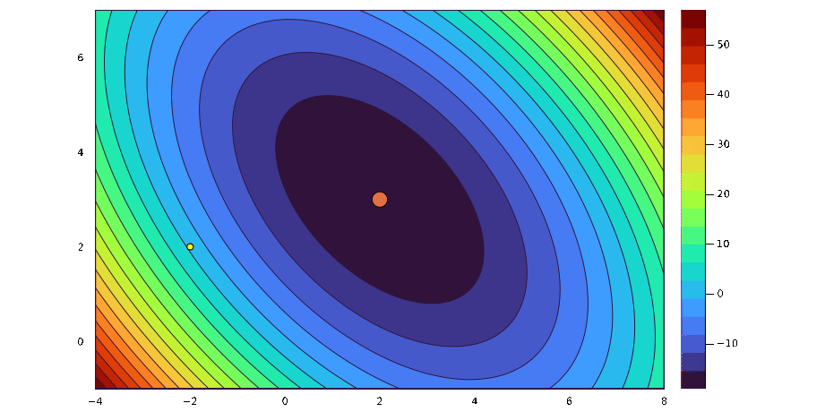

## Illustration of Richardson’s method: $\omega = .6$

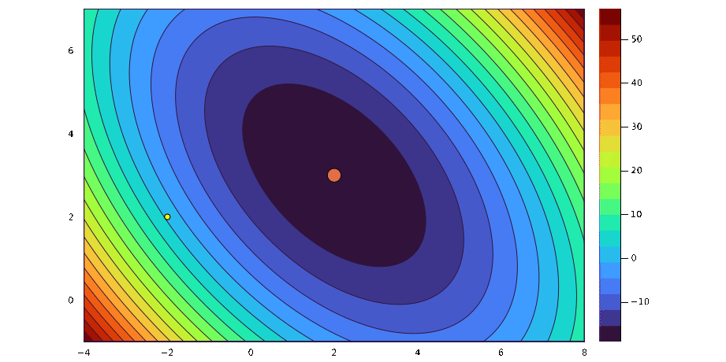

## Illustration of Richardson’s method: optimal $\omega = .5$

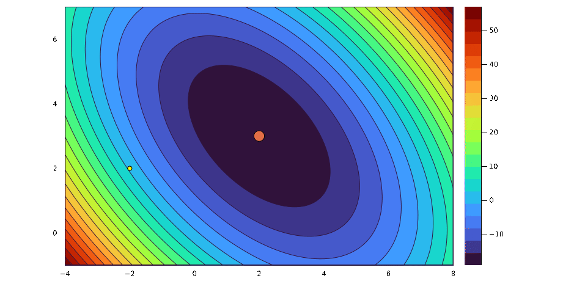

## More general basic iterative methods

Consider the splitting
$$\mathsf A = {\color{green}\mathsf M} - {\color{blue} \mathsf N}$$
where $\mathsf M$ is invertible and easy to invert. Then
$$\mathsf A \mathbf{\boldsymbol{x}}_* = \mathbf{\boldsymbol{b}} \quad \Leftrightarrow \quad
{\color{green}\mathsf M} \mathbf{\boldsymbol{x}}_* = {\color{blue} \mathsf N} \mathbf{\boldsymbol{x}}_* + \mathbf{\boldsymbol{b}}$$
which suggests the iterative method
$${\color{green}\mathsf M} \mathbf{\boldsymbol{x}}^{(k+1)} = {\color{blue} \mathsf N} \mathbf{\boldsymbol{x}}^{(k)} + \mathbf{\boldsymbol{b}}$$

**Standard basic iterative methods (here $\mathsf A = \mathsf L + \mathsf D + \mathsf U$)**

- Richardson’s iteration corresponds to the particular splitting

$$\mathsf A = \underbrace{{\color{green}\frac{1}{\omega} \mathsf I }}_{\mathsf M} - \underbrace{\left({\color{blue} \frac{1}{\omega} \mathsf I - \mathsf A}\right)}_{\mathsf N}$$

- Jacobi’s iteration: $\mathsf A = {\color{green}\mathsf D} - ({\color{blue}-\mathsf L - \mathsf U})$.
- Gauss Seidel’s iteration: $\mathsf A = ({\color{green}\mathsf D + \mathsf L}) - ({\color{blue}- \mathsf U})$
- Relaxation method: $\mathsf A = \left({\color{green}\frac{\mathsf D}{\omega} + \mathsf L }\right) - \left({\color{blue}\frac{1 - \omega}{\omega} \mathsf D - \mathsf U} \right)$. $~$(Coincides with Gauss-Seidel when $\omega = 1$)

## Convergence of general basic iterative method

**Proposition: convergence of the splitting method**

- The iteration
  $${\color{green}\mathsf M} \mathbf{\boldsymbol{x}}^{(k+1)} = {\color{blue} \mathsf N} \mathbf{\boldsymbol{x}}^{(k)} + \mathbf{\boldsymbol{b}}$$
  converges for any initial $\mathbf{\boldsymbol{x}}^{(0)}$ if and only if $\rho({\color{green}\mathsf M}^{-1} {\color{blue} \mathsf N}) < 1$.
- In addition, for any $\varepsilon > 0$ there exists $K > 0$ such that
  $$\forall k \geqslant K,
  \qquad
  {\lVert {\mathbf{\boldsymbol{x}}^{(k)} - \mathbf{\boldsymbol{x}}_*} \rVert} \leqslant\bigl(\rho({\color{green}\mathsf M}^{-1} {\color{blue} \mathsf N}) + \varepsilon\bigr)^k {\lVert {\mathbf{\boldsymbol{x}}^{(0)} - \mathbf{\boldsymbol{x}}_*} \rVert}.$$

**Proof**

Subtracting the equations
$$\begin{aligned}
{\color{green}\mathsf M} \mathbf{\boldsymbol{x}}^{(k+1)} &= {\color{blue} \mathsf N} \mathbf{\boldsymbol{x}}^{(k)} + \mathbf{\boldsymbol{b}} \\
{\color{green}\mathsf M} \mathbf{\boldsymbol{x}}_* &= {\color{blue} \mathsf N} \mathbf{\boldsymbol{x}}_* + \mathbf{\boldsymbol{b}}
\end{aligned}$$
and rearranging gives
$$\mathbf{\boldsymbol{x}}^{(k+1)} - \mathbf{\boldsymbol{x}}_*
= {\color{green}\mathsf M}^{-1} {\color{blue} \mathsf N} (\mathbf{\boldsymbol{x}}^{(k)} - \mathbf{\boldsymbol{x}}_*)
= \dots = ({\color{green}\mathsf M}^{-1} {\color{blue} \mathsf N})^{k+1} (\mathbf{\boldsymbol{x}}^{(0)} - \mathbf{\boldsymbol{x}}_*).$$
The “only if” part of the first item is simple. The other claims follow from Gelfand’s formula:
$$\forall \mathsf B \in \mathbf C^{n \times n}, \qquad
\lim_{k \to \infty} {\lVert {\mathsf B^k} \rVert}^{1/k} = \rho(\mathsf B).$$

## Concrete convergence guarantees

Settings where $\rho(\mathsf M^{-1} \mathsf N) < 1$ are identified on a case by case basis:

$$\lvert a_{ii} \rvert > \sum_{j \neq i} \lvert a_{ij} \rvert \quad \forall i
\qquad \text{ or } \qquad
\lvert a_{jj} \rvert > \sum_{i \neq j} \lvert a_{ij} \rvert \quad \forall j.$$

- Gauss Seidel’s iteration, sufficient condition: $\mathsf A$ strictly row or column diagonally dominant;
- Relaxation method, sufficient condition: $\mathsf A$ symmetric positive definite and $\omega \in (0, 2)$;
- Relaxation method, necessary condition: $\omega \in (0, 2)$;
- …

## Improving upon Richardson’s iteration

**We suppose again, until the end of this lecture, that $\mathsf A$ is symmetric positive definite**

We recall Richardson’s iteration:
$$\begin{align*}
\mathbf{\boldsymbol{x}}^{(k + 1)} = \mathbf{\boldsymbol{x}}^{(k)} - \omega \nabla f(\mathbf{\boldsymbol{x}}^{(k)}), \qquad f(\mathbf{\boldsymbol{x}}) := \frac{1}{2} \mathbf{\boldsymbol{x}}^T\mathsf A \mathbf{\boldsymbol{x}} - \mathbf{\boldsymbol{b}}^T\mathbf{\boldsymbol{x}}.
\end{align*}$$

**Proposition**

For any $\mathbf{\boldsymbol{d}} \in \mathbf R^n$, it holds that
$$\mathop{\mathrm{arg\,min}}_{\omega \in \mathbf R} f \left(\mathbf{\boldsymbol{x}} - \omega \mathbf{\boldsymbol{d}} \right) = \frac{\mathbf{\boldsymbol{d}}^T\mathbf{\boldsymbol{r}}}{\mathbf{\boldsymbol{d}}^T\mathsf A \mathbf{\boldsymbol{d}}},
\qquad \mathbf{\boldsymbol{r}} = \mathsf A \mathbf{\boldsymbol{x}} - \mathbf{\boldsymbol{b}}.$$

We can improve upon Richardson’s iteration by letting
$$\mathbf{\boldsymbol{x}}^{(k + 1)} = \mathbf{\boldsymbol{x}}^{(k)} - \omega_{\color{red}k} \nabla f(\mathbf{\boldsymbol{x}}^{(k)}),
\qquad \omega_{\color{red}k} := \frac{\mathbf{\boldsymbol{d}}_k^T\mathbf{\boldsymbol{d}}_k}{\mathbf{\boldsymbol{d}}_k^T\mathsf A \mathbf{\boldsymbol{d}}_k},
\qquad \mathbf{\boldsymbol{d}}_k := \mathsf A \mathbf{\boldsymbol{x}}^{(k)} - \mathbf{\boldsymbol{b}}.$$

This is the steepest descent method with optimal step.

## Illustration of steepest descent

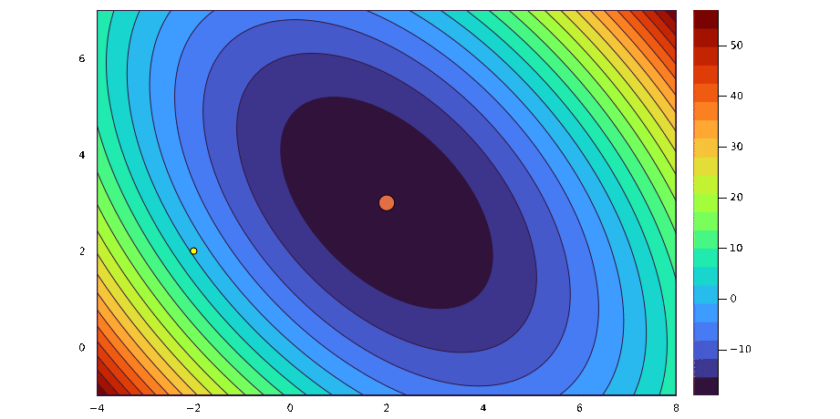

## Further improvement: the conjugate directions method

First note that
$$f(\mathbf{\boldsymbol{x}})
= \frac{1}{2} \mathbf{\boldsymbol{x}}^T\mathsf A \mathbf{\boldsymbol{x}} - \mathbf{\boldsymbol{b}}^T\mathbf{\boldsymbol{x}}
= \frac{1}{2} {\lVert {\mathbf{\boldsymbol{x}} - \mathbf{\boldsymbol{x}}_*} \rVert}_{\mathsf A}^2 + \text{constant},
\qquad {\lVert {\mathbf{\boldsymbol{y}}} \rVert}_{\mathsf A} := \sqrt{{\langle {\mathbf{\boldsymbol{y}}, \mathbf{\boldsymbol{y}}} \rangle}_{\mathsf A}},
\qquad {\langle {\mathbf{\boldsymbol{x}}, \mathbf{\boldsymbol{y}}} \rangle}_{\mathsf A} := \mathbf{\boldsymbol{x}}^T\mathsf A \mathbf{\boldsymbol{y}}.$$
Given $n$ conjugate directions $\{\mathbf{\boldsymbol{d}}_0, \dotsc, \mathbf{\boldsymbol{d}}_{n-1}\}$ such that ${\langle {\mathbf{\boldsymbol{d}}_i, \mathbf{\boldsymbol{d}}_j} \rangle}_{\mathsf A} = \delta_{ij}$, we have
$$\mathbf{\boldsymbol{x}}_* - \mathbf{\boldsymbol{x}}^{(0)}
= \sum_{i=0}^{n-1} \mathbf{\boldsymbol{d}}_i \mathbf{\boldsymbol{d}}_i^T\mathsf A (\mathbf{\boldsymbol{x}}_* - \mathbf{\boldsymbol{x}}^{(0)})
= \sum_{i=0}^{n-1} \mathbf{\boldsymbol{d}}_i \mathbf{\boldsymbol{d}}_i^T({\color{green}\mathbf{\boldsymbol{b}}} - \mathsf A \mathbf{\boldsymbol{x}}^{(0)})$$

$\color{green}\rightarrow$ the $\mathsf A$-projections of $\mathbf{\boldsymbol{x}}_* - \mathbf{\boldsymbol{x}}^{(0)}$ can be calculated even though $\mathbf{\boldsymbol{x}}_*$ is unknown!

```julia
# Assume `ds` is a list of n conjugate directions
x = zeros(n)
for k in 1:n
    d = ds[k]
    r = A*x - b
    ω = d'r / (d'A*d)  # Denominator = 1 if `d` is normalized
    x -= ω * d
end
```

**Minimization property**: by construction,

- $\mathbf{\boldsymbol{x}}^{(k)} - \mathbf{\boldsymbol{x}}^{(0)}$ is the $\mathsf A$-orthogonal projection of $\mathbf{\boldsymbol{x}}_* - \mathbf{\boldsymbol{x}}^{(0)}$ onto $\mathop{\mathrm{Span}}\{\mathbf{\boldsymbol{d}}_0, \dotsc, \mathbf{\boldsymbol{d}}_{k-1}\}$.
- Therefore, $\mathbf{\boldsymbol{x}}^{(k)}$ minimizes $f(\mathbf{\boldsymbol{x}}^{(k)})$ over the full affine subspace $\mathbf{\boldsymbol{x}}^{(0)} + \mathop{\mathrm{Span}}\{\mathbf{\boldsymbol{d}}_0, \dotsc, \mathbf{\boldsymbol{d}}_{k-1}\}$.

## Conjugate directions: example

- Consider again the linear system
  $$\begin{pmatrix}
  2 & 1 \\ 1 & 2
  \end{pmatrix}
  \begin{pmatrix}
  x_1 \\ x_2
  \end{pmatrix}
  =
  \begin{pmatrix}
  7 \\ 8
  \end{pmatrix}$$
- (non-normalized) Conjugate directions calculated by Gram-Schmidt:
  $$\mathbf{\boldsymbol{d}}_0 =
  \begin{pmatrix}
  1 \\ 0
  \end{pmatrix}, \qquad
  \mathbf{\boldsymbol{d}}_1 =
  \begin{pmatrix}
  -1 \\ 2
  \end{pmatrix}.$$

```julia
using LinearAlgebra
n = 2
A = [2.0 1.0; 1.0 2.0]
b = [7.0; 8.0]
x = zeros(n)
ds = [[1.0; 0.0], [-1.0; 2.0]]
for i in 1:n
    d = ds[i]
    r = A*x - b
    ω = d'r / (d'A*d)  # Denominator useful if `d` is not normalized
    x -= ω*d
    println("Residual: $(norm(A*x - b))")
end
```

```
Residual: 4.5
Residual: 0.0
```

## Conjugate directions: illustration

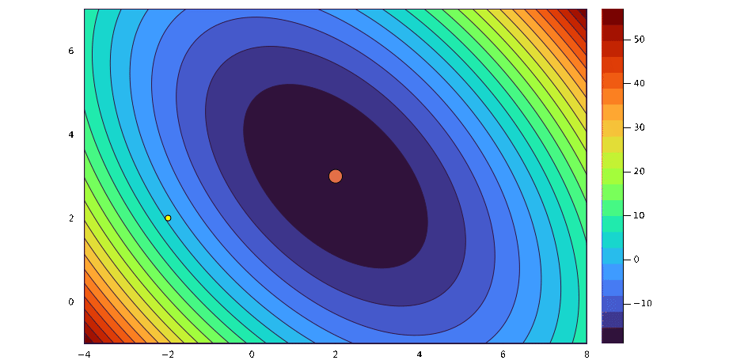

- In general, convergence in at most $n$ iterations;
- **Question**: how to generate conjugate directions ?

  ${\color{green} \rightarrow}$ the **conjugate gradient method** enables to generate conjugate directions on the fly.

## Conjugate gradient method

- **Idea**: generate conjugate direction $\mathbf{\boldsymbol{d}}_k$ by applying Gram-Schmidt to $\mathbf{\boldsymbol{r}}^{(0)}, \mathbf{\boldsymbol{r}}^{(1)}, \dotsc, \mathbf{\boldsymbol{r}}^{(k)}$.
- Cost of calculating a new direction $\mathbf{\boldsymbol{d}}_k$ seemingly scales as $\mathcal O(k)$, but in fact $\color{green} \mathcal O(1)$.
- **Convergence**: exact in $n$ iterations, and otherwise faster than Richardson’s iteration:

**Theorem**

Suppose that $\mathsf A$ is symmetric positive definite. Then
$$\forall k \geqslant 0, \qquad
{\lVert {\mathbf{\boldsymbol{x}}^{(k)} - \mathbf{\boldsymbol{x}}_*} \rVert}_{\mathsf A} \leqslant 2 \left( \frac{{\color{red}\sqrt{\kappa_2(\mathsf A)}} - 1}{{\color{red}\sqrt{\kappa_2(\mathsf A)}} + 1} \right)^{k} {\lVert {\mathbf{\boldsymbol{x}}^{(0)} - \mathbf{\boldsymbol{x}}_*} \rVert}_{\mathsf A},$$

## Conjugate gradient method: illustration

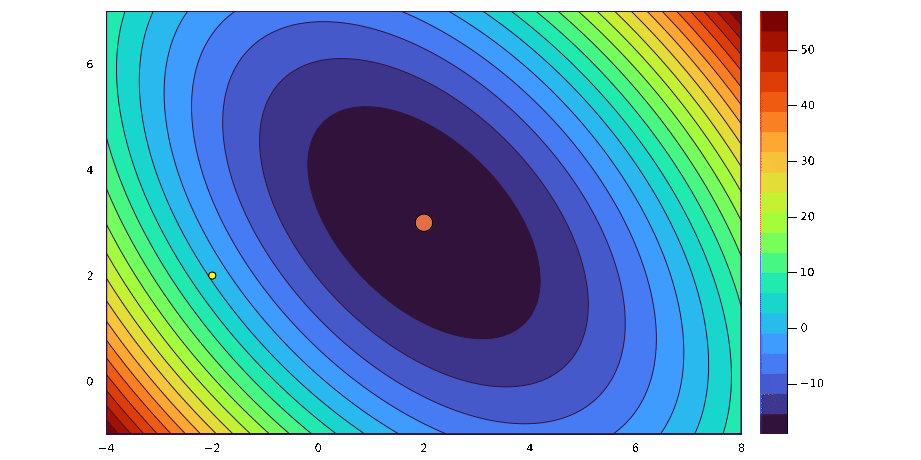